# Formulaire de réponse pour le test 1

**Jonathan MAROTTA - G4**

### Question 1

- Calculer la probabilité pour que le candidat réussisse l’examen.

#### Réponse :

D’après l’énoncé, chaque épreuve peut être vue comme une variable aléatoire suivant une loi de Bernouilli de paramètre $p=1-q=0,98$.

Les 10 épreuves à valider pour qu’un candidat réussisse l’examen étant indépendantes et suivant toutes la même loi de Bernouilli de paramètre p=0,98, et puisque l’on s’intéresse au nombre d’occurrences $N$ de réussites, la variable aléatoire associée à cette expérience (enchainement de 10 épreuves identiques et indépendantes) peut être vue comme une variable aléatoire N suivant une loi binomiale de paramètre $n=10$ et $p=0,98$, avec :

$$P(N=i) = \binom{n}{i} \cdot p^i \cdot
(1-p)^{n-i}$$

et

$$E[N] = \sum_{i=1}^n i \cdot P(N=i) =
np$$

Pour qu’il réussisse l’examen, l’étudiant doit réussir chacune des 10 épreuves, on cherche donc ici :

$$P(N=10) = \binom{10}{10} * 0,98^{10} *
0,02^0 = 0,98^{10} \simeq 0,817$$

- Déterminer l’espérance du nombre de candidats réussissant l’examen.

#### Réponse :

Cette nouvelle expérience peut également être représentée par une variable aléatoire Y suivant une loi binomiale, cette fois-ci de paramètre $n=240$ et $p=0,98^{10}$. D’où:

$$E[Y] = 240 * 0,98^{10} \simeq
196,1$$

L’espérance est de 196 étudiants réussissants l’examen.

### Question 2

- Calculer les probabilités P($N = i$), pour tout $i$ de 1 à 4.

#### Réponse :

Après dénombrement, on a :

$P(N_1 > N_2) = \frac{6}{16} = \frac{3}{8}$  
$P(N_1 \leq N_2) = \frac{10}{16} = \frac{5}{8}$  
$P(N_1 \leq N_2 \bigcap N_2=1) = \frac{1}{16}$  
$P(N_1 \leq N_2 \bigcap N_2=2) = \frac{2}{16} = \frac{1}{8}$  
$P(N_1 \leq N_2 \bigcap N_2=3) = \frac{3}{16}$  
$P(N_1 \leq N_2 \bigcap N_2=4) = \frac{4}{16} = \frac{1}{4}$

D’après l’énoncé, on note $N$ la réalisation de la variable $N_2$ **à l’issue de cette expérience**, c’est-à-dire **sachant que** la condition $(N_1 \leq N_2)$ est réalisée. On a donc :

$P(N=i) = P(N_2=i | N_1 \leq N_2)$

D’où :

$P(N=1) = P(N_2=1 | N_1 \leq N_2)$  
$P(N=1) = \frac{P(N_2=1 \bigcap N_1 \leq N_2)}{P(N_1 \leq N_2)}$  
$P(N=1) = \frac{\frac{1}{16}}{\frac{5}{8}}$  
$P(N=1) = \frac{1}{16} * \frac{8}{5}$  
$P(N=1) = \frac{1}{10}$

De même on obtient :

$P(N=2) = \frac{\frac{1}{8}}{\frac{5}{8}} = \frac{1}{5}$  
$P(N=3) = \frac{\frac{3}{16}}{\frac{5}{8}} = \frac{3}{10}$  
$P(N=4) = \frac{\frac{1}{4}}{\frac{5}{8}} = \frac{2}{5}$

### Question 3

- Calculer la probabilité de l’événement $G$ sachant que le candidat change de porte. Calculer la probabilité de l’événement $G$ sachant que le candidat conserve son choix initial.

#### Réponse :

A la première étape, le candidat choisit une porte au hasard parmi les trois, avec équiprobabilité de choisir chacune des trois portes, et donc une probabilité associée à chaque porte $P_1 = \frac{1}{3}$.

Notons les évènements :  
* C1 = “le candidat a choisi la chèvre1 à la première étape”  
* C2 = “le candidat a choisi la chèvre2 à la première étape”  
* V = “le candidat a choisi la voiture à la première étape”

A la seconde étape, le présentateur désigne alors parmi les deux autres portes celle/une contenant une chèvre. Selon le choix initial du candidat, les probabilités de ce qui est désigné varient :

- Si le candidat a choisit C1 ou C2, le présentateur désignera C2 ou C1 respectivement avec une probabilité $P_2 = 1$.
- En revanche, si le candidat a choisit V, alors le présentateur désignera C1 ou C2 avec $P_2 = \frac{1}{2}$ pour chacune des deux possibilités.

E la troisième étape, le candidat décide de changer ou non de choix avec une probabilité $P_3 = \frac{1}{2}$.

On obtient finalement l’arbre des probabilités suivant :

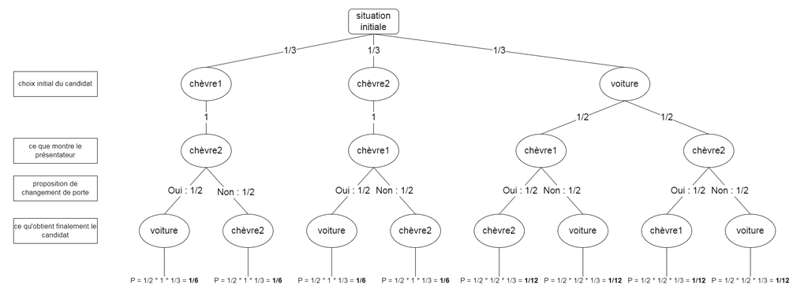

Et :

$P(C|G) = \frac{P(C \cap G)}{P(G)} = \frac{\frac{1}{6} + \frac{1}{6}}{\frac{1}{2}} = \frac{2}{3}$  
$P(G|\bar C) = \frac{P(G \cap \bar C)}{P(\bar C)} = \frac{\frac{1}{12} + \frac{1}{12}}{\frac{1}{2}} = \frac{1}{3}$

On peut remarquer qu’il est préférable de changer de porte pour avoir une probabilité de gagner plus élevée.

### Question 4

- Le candidat opte a priori pour une stratégie aléatoire. Il change de porte avec la probabilité $p = 1/3$. Puis il joue et gagne le jeu. Quelle est la probabilité que le candidat ait changé de porte ?

#### Réponse :

On obtient ce nouvel arbre des probabilités :

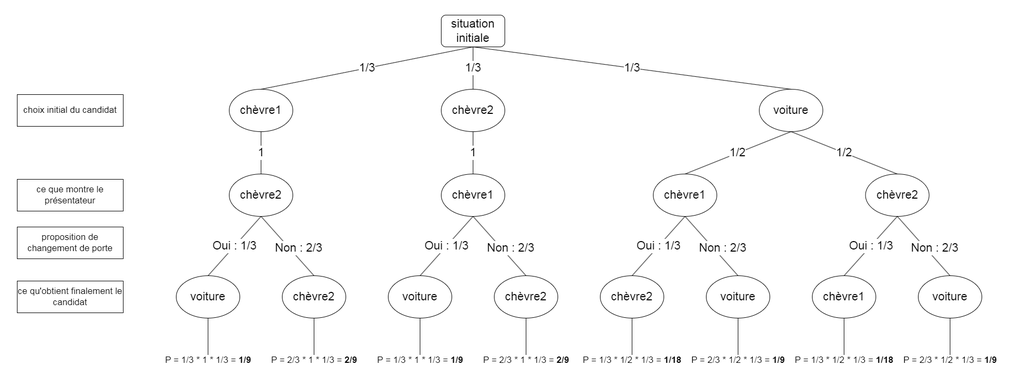

```
Et :
```

$P(C|G) = \frac{P(C \cap G)}{P(G)} = \frac{\frac{1}{9} + \frac{1}{9}}{\frac{1}{9} + \frac{1}{9} + \frac{1}{9} + \frac{1}{9}} = \frac{\frac{2}{9}}{\frac{4}{9}} = \frac{2}{9} * \frac{9}{4} = \frac{1}{2}$

(Avec cette façon de procéder, il y a autant de “chance” de gagner au jeu que l’on change ou non de porte.)

### Question 5

- Calculer la valeur médiane de la variable $X$.

#### Réponse :

De plus, N est une variable aléatoire étagée avec :

$P(N=1) = \frac{1}{2}$  
$P(N=2) = \frac{1}{3}$  
$P(N=3) = \frac{1}{6}$

On sait que $X=N*U$, et $U$ et $N$ sont indépendantes.  
On recherche ici la médiane de X, c’est-à-dire la valeur $x$ pour laquelle $P(X \leq x) = P(X \geq x) = \frac{1}{2}$.

On a donc la médiane de $X$ qui vaut $\frac{9}{13}$.

(Remarque : si $x$ > 1 , on peut toujours écrire $P(U \leq x) = P(U \leq 1 \bigcup 1 < U \leq x) = P(U \leq 1) + P(1 < U \leq x)$ puisque ces deux derniers évènements sont disjoints. Et comme $P(1 < U \leq x)= 0$, le calcul ne change pas.

De même pour les cas $\frac{x}{2} > 1$ ou $\frac{x}{2} > 1$.)

### Question 6

#### Réponse :

- $P(Z_n > t) = P[(X_1 > t) \bigcap (X_2 > t) \bigcap$ … $\bigcap (X_n > t)]$.

Or les $X_i$ sont indépendants d’après l’énoncé, d’où :

$$P(Z_n > t) = P(X_1 > t) * P(X_2
> t) * ... * P(X_n > t)]$$
$$P(Z_n > t) = \prod_{1}^{n}
exp(-µt)$$
$$P(Z_n > t) = (exp(-µt))^n$$
$$P(Z_n > t) = exp(-nµt)$$

### Question 7

- Déterminer la loi de la variable $Z$. Donner son espérance.

#### Réponse :

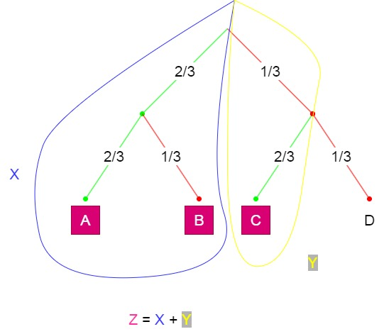

- L’énoncé n’étant pas suffisamment explicite, je choisis de comprendre “On définit la variable aléatoire $Z$ égale au nombre de joueurs ayant atteint la cible au premier **et/ou** au second tir”.

$Z \sim B(20,\frac{8}{9})$.

En effet, $P($“l’archer touche au premier et/ou au second tir”$)$ = $\frac{2}{3} \cdot \frac{2}{3} + \frac{1}{3} \cdot \frac{2}{3} + \frac{2}{3} \cdot \frac{1}{3} = \frac{4}{9} + \frac{2}{9} + \frac{2}{9} = \frac{8}{9}$.

D’où la loi de $Z$ (avec $i$ le nombre d’archers touchant au premier et/ou au second tir) :

[output not shown]

[output not shown]

[output not shown]

avec $P(Z=i) = \binom{20}{i} \cdot p^i \cdot (1-p)^{n-i}$

$P(Z=0) = \binom{20}{0} \cdot (\frac{8}{9})^0 \cdot (\frac{1}{9})^{20} = (\frac{1}{9})^{20}$ $P(Z=1) = \binom{20}{1} \cdot (\frac{8}{9})^1 \cdot (\frac{1}{9})^{19} = \frac{160}{9} \cdot (\frac{1}{9})^{19}$  
$P(Z=2) = \binom{20}{2} \cdot (\frac{8}{9})^2 \cdot (\frac{1}{9})^{18} = \frac{20*19*64}{81} \cdot (\frac{1}{9})^{18} = \frac{24320}{2*81} \cdot (\frac{1}{9})^{18} = \frac{12160}{81} \cdot (\frac{1}{9})^{18}$

…

$E[Z] = np = 20*\frac{8}{9} = \frac{160}{9} \simeq 17,78$

- $Y = Z - X$

### Question 8

- Déterminer la loi de la variable $Y$. Donner son espérance.

#### Réponse :

- $Y \sim B(20,\frac{2}{9})$.

En effet, $P($“l’archer loupe au premier tir et touche au second tir”$)$ = $\frac{1}{3} \cdot \frac{2}{3} = \frac{2}{9}$ et on répète cette expérience identique pour chacun des 20 archers. D’où avec n = 20 :

$P(Y=i) = \binom{20}{i} \cdot (\frac{2}{9})^i \cdot (\frac{7}{9})^{20-i}$

$E[Y] = 20 * \frac{2}{9} = \frac{40}{9}$

### Question 9

- Donner une relation simple liant ${\rm E}[XY]$ à l’espérance d’une fonction simple de $X$ et la valeur de cette espérance (une ligne).

#### Réponse :

$$E[XY] = E[(X-E[X])\cdot(Y-E[Y])] + E[X]
\cdot E[Y]$$

### Question 10

- Calculer la variance de la variable aléatoire $Z$. En déduire la covariance du couple $(X,Y)$ et retrouver le résultat précédent (une ligne).

#### Réponse :

Si $W$ une variable aléatoire et $W \sim B(n,p)$, alors $Var(W) = np(1-p)$.  
Puisque $Z \sim B(20,\frac{8}{9})$, alors :

$Var(Z) = 20*\frac{8}{9} * \left( 1-\frac{8}{9} \right) = 20*\frac{8}{9} * \frac{1}{9} = \frac{160}{81} \simeq 1,98$

Et :